# Lab: Basic Data Manipulation in R

Xuemao Zhang

June 24, 2019

## Introduction

- Data sets: We use two hypothetical data sets students1.csv and students2.csv to show how to do basic data manipulations in R.
- The file `students1.csv` contains 30 students’ basic information, and two numerical variables: `Age` and `SAT`.
- The file `students2.csv` contains two numerical variables: a course `grade` and `Height(in)` of 25 students from `students1.csv` (5 of them are missing).
- We want to study these four variables and the relationship among the variables.
- Merging two datasets require that both have at least one variable in common (either string or numeric).
- Explore each dataset separately before merging. Make sure to use all possible common variables.
- In this session, we consider some basic data manipulation methods using R:
  - Merging data
  - Adding variables
  - Checking missing values
  - Replacing values
  - Selecting variables
  - Removing missing values
  - Removing variables
  - Renaming variables
  - Subsetting observations

## Data structures

- We have data in two separate datasets and we’d like to combine based on two variables: students’ last name and first name.

```r
students1=read.csv("F:/DataCamp/data/students1.csv",header=TRUE, sep=",");
students2=read.csv("F:/DataCamp/data/students2.csv",header=TRUE, sep=",");
dim(students1);
```

```
## [1] 30  8
```

```r
str(students1);
```

```
## 'data.frame':    30 obs. of  8 variables:
##  $ Last.Name     : Factor w/ 15 levels "DOE01","DOE02",..: 1 2 1 2 3 4 5 3 4 5 ...
##  $ First.Name    : Factor w/ 30 levels "JANE01","JANE02",..: 1 2 16 17 18 19 20 3 4 5 ...
##  $ Gender        : Factor w/ 2 levels "Female","Male": 1 1 2 2 2 2 2 1 1 1 ...
##  $ Student.Status: Factor w/ 2 levels "Graduate","Undergraduate": 1 2 1 1 1 1 1 2 2 1 ...
##  $ Major         : Factor w/ 3 levels "Econ","Math",..: 3 2 2 1 1 1 3 3 2 2 ...
##  $ Country       : Factor w/ 11 levels "Argentina","Bulgaria",..: 10 10 10 10 10 6 10 10 3 10 ...
##  $ Age           : int  30 19 26 33 37 25 39 21 18 33 ...
##  $ SAT           : int  2263 2006 2221 1716 1701 1786 1577 1842 1813 2041 ...
```

```r
head(students1);
```

```
##   Last.Name First.Name Gender Student.Status    Major Country Age  SAT
## 1     DOE01     JANE01 Female       Graduate Politics      US  30 2263
## 2     DOE02     JANE02 Female  Undergraduate     Math      US  19 2006
## 3     DOE01      JOE01   Male       Graduate     Math      US  26 2221
## 4     DOE02      JOE02   Male       Graduate     Econ      US  33 1716
## 5     DOE03      JOE03   Male       Graduate     Econ      US  37 1701
## 6     DOE04      JOE04   Male       Graduate     Econ  Israel  25 1786
```

```r
dim(students2);
```

```
## [1] 25  5
```

```r
str(students2);
```

```
## 'data.frame':    25 obs. of  5 variables:
##  $ Last.Name : Factor w/ 15 levels "DOE01","DOE02",..: 1 2 1 2 4 5 3 4 6 6 ...
##  $ First.Name: Factor w/ 25 levels "JANE01","JANE02",..: 1 2 13 14 15 16 3 4 17 5 ...
##  $ Gender    : Factor w/ 2 levels "Female","Male": 1 1 2 2 2 2 1 1 2 1 ...
##  $ Grade     : int  67 63 78 78 69 96 87 91 82 79 ...
##  $ Height    : int  61 64 73 68 67 70 62 62 67 59 ...
```

```r
head(students2);
```

```
##   Last.Name First.Name Gender Grade Height
## 1     DOE01     JANE01 Female    67     61
## 2     DOE02     JANE02 Female    63     64
## 3     DOE01      JOE01   Male    78     73
## 4     DOE02      JOE02   Male    78     68
## 5     DOE04      JOE04   Male    69     67
## 6     DOE05      JOE05   Male    96     70
```

## Data merging

- `merge()` function is used to combine the two data sets.
- When common ids have different names, we use by.x and by.y to match them. In this example, we use `by` to specify the common variables.
- The option `all=TRUE` includes all data from both datasets.
- The merged data set is a data frame. The columns are the common columns followed by the remaining columns in the first data set and then those in the second data set.
- If a common variable (`Gender` here) is not specified, the merged data keep both variables. Here they are `Gender.x` and `Gender.y`.

```r
students=merge(students1, students2, by=c("Last.Name","First.Name"), all=TRUE);
str(students);
```

```
## 'data.frame':    30 obs. of  11 variables:
##  $ Last.Name     : Factor w/ 15 levels "DOE01","DOE02",..: 1 1 2 2 3 3 4 4 5 5 ...
##  $ First.Name    : Factor w/ 30 levels "JANE01","JANE02",..: 1 16 2 17 3 18 4 19 5 20 ...
##  $ Gender.x      : Factor w/ 2 levels "Female","Male": 1 2 1 2 1 2 1 2 1 2 ...
##  $ Student.Status: Factor w/ 2 levels "Graduate","Undergraduate": 1 1 2 1 2 1 2 1 1 1 ...
##  $ Major         : Factor w/ 3 levels "Econ","Math",..: 3 2 2 1 3 1 2 1 2 3 ...
##  $ Country       : Factor w/ 11 levels "Argentina","Bulgaria",..: 10 10 10 10 10 10 3 6 10 10 ...
##  $ Age           : int  30 26 19 33 21 37 18 25 33 39 ...
##  $ SAT           : int  2263 2221 2006 1716 1842 1701 1813 1786 2041 1577 ...
##  $ Gender.y      : Factor w/ 2 levels "Female","Male": 1 2 1 2 1 NA 1 2 NA 2 ...
##  $ Grade         : int  67 78 63 78 87 NA 91 69 NA 96 ...
##  $ Height        : int  61 73 64 68 62 NA 62 67 NA 70 ...
```

```r
dim(students);
```

```
## [1] 30 11
```

```r
head(students);
```

```
##   Last.Name First.Name Gender.x Student.Status    Major Country Age  SAT
## 1     DOE01     JANE01   Female       Graduate Politics      US  30 2263
## 2     DOE01      JOE01     Male       Graduate     Math      US  26 2221
## 3     DOE02     JANE02   Female  Undergraduate     Math      US  19 2006
## 4     DOE02      JOE02     Male       Graduate     Econ      US  33 1716
## 5     DOE03     JANE03   Female  Undergraduate Politics      US  21 1842
## 6     DOE03      JOE03     Male       Graduate     Econ      US  37 1701
##   Gender.y Grade Height
## 1   Female    67     61
## 2     Male    78     73
## 3   Female    63     64
## 4     Male    78     68
## 5   Female    87     62
## 6     <NA>    NA     NA
```

## Add variables

- We add an `ID` variable from 1 to `n`, the number of observations.

```r
students$ID = seq(dim(students)[1]);
str(students);
```

```
## 'data.frame':    30 obs. of  12 variables:
##  $ Last.Name     : Factor w/ 15 levels "DOE01","DOE02",..: 1 1 2 2 3 3 4 4 5 5 ...
##  $ First.Name    : Factor w/ 30 levels "JANE01","JANE02",..: 1 16 2 17 3 18 4 19 5 20 ...
##  $ Gender.x      : Factor w/ 2 levels "Female","Male": 1 2 1 2 1 2 1 2 1 2 ...
##  $ Student.Status: Factor w/ 2 levels "Graduate","Undergraduate": 1 1 2 1 2 1 2 1 1 1 ...
##  $ Major         : Factor w/ 3 levels "Econ","Math",..: 3 2 2 1 3 1 2 1 2 3 ...
##  $ Country       : Factor w/ 11 levels "Argentina","Bulgaria",..: 10 10 10 10 10 10 3 6 10 10 ...
##  $ Age           : int  30 26 19 33 21 37 18 25 33 39 ...
##  $ SAT           : int  2263 2221 2006 1716 1842 1701 1813 1786 2041 1577 ...
##  $ Gender.y      : Factor w/ 2 levels "Female","Male": 1 2 1 2 1 NA 1 2 NA 2 ...
##  $ Grade         : int  67 78 63 78 87 NA 91 69 NA 96 ...
##  $ Height        : int  61 73 64 68 62 NA 62 67 NA 70 ...
##  $ ID            : int  1 2 3 4 5 6 7 8 9 10 ...
```

## Check missing values

- It can be seen that some data values are missing. Recall that 5 students are missing in the second data set students2.
- The function `complete.cases()` returns a logical vector indicating which cases(rows) are complete.
- The function `na.omit` is used to remove rows with missing values.

```r
rowSums(is.na(students)); # Number of missing per row
```

```
##  [1] 0 0 0 0 0 3 0 0 3 0 0 0 0 0 3 0 3 0 0 0 0 3 0 0 0 0 0 0 0 0
```

```r
colSums(is.na(students)); # Number of missing per column
```

```
##      Last.Name     First.Name       Gender.x Student.Status          Major
##              0              0              0              0              0
##        Country            Age            SAT       Gender.y          Grade
##              0              0              0              5              5
##         Height             ID
##              5              0
```

```r
students[!complete.cases(students),];# list rows of data that have missing values
```

```
##    Last.Name First.Name Gender.x Student.Status    Major Country Age  SAT
## 6      DOE03      JOE03     Male       Graduate     Econ      US  37 1701
## 9      DOE05     JANE05   Female       Graduate     Math      US  33 2041
## 15     DOE08     JANE08   Female  Undergraduate     Econ      US  18 1821
## 17     DOE09     JANE09   Female  Undergraduate     Math Holland  19 1494
## 22     DOE11      JOE11     Male  Undergraduate Politics  Sweden  19 1919
##    Gender.y Grade Height ID
## 6      <NA>    NA     NA  6
## 9      <NA>    NA     NA  9
## 15     <NA>    NA     NA 15
## 17     <NA>    NA     NA 17
## 22     <NA>    NA     NA 22
```

- From this output we can see that 5 students have missing values for the three variables `Gender.y`, `Grade` and `Height`.

## Replace a value

- First, we replace the missing values of the variable `Gender.y` by the corresponding `Gender.x`.

```r
students$Gender.y=ifelse(is.na(students$Gender.y), as.character(students$Gender.x), as.character(students$Gender.y));  #use as.character() to avoid Gender.y converted from factor to numerical
students[!complete.cases(students),];
```

```
##    Last.Name First.Name Gender.x Student.Status    Major Country Age  SAT
## 6      DOE03      JOE03     Male       Graduate     Econ      US  37 1701
## 9      DOE05     JANE05   Female       Graduate     Math      US  33 2041
## 15     DOE08     JANE08   Female  Undergraduate     Econ      US  18 1821
## 17     DOE09     JANE09   Female  Undergraduate     Math Holland  19 1494
## 22     DOE11      JOE11     Male  Undergraduate Politics  Sweden  19 1919
##    Gender.y Grade Height ID
## 6      Male    NA     NA  6
## 9    Female    NA     NA  9
## 15   Female    NA     NA 15
## 17   Female    NA     NA 17
## 22     Male    NA     NA 22
```

```r
str(students);
```

```
## 'data.frame':    30 obs. of  12 variables:
##  $ Last.Name     : Factor w/ 15 levels "DOE01","DOE02",..: 1 1 2 2 3 3 4 4 5 5 ...
##  $ First.Name    : Factor w/ 30 levels "JANE01","JANE02",..: 1 16 2 17 3 18 4 19 5 20 ...
##  $ Gender.x      : Factor w/ 2 levels "Female","Male": 1 2 1 2 1 2 1 2 1 2 ...
##  $ Student.Status: Factor w/ 2 levels "Graduate","Undergraduate": 1 1 2 1 2 1 2 1 1 1 ...
##  $ Major         : Factor w/ 3 levels "Econ","Math",..: 3 2 2 1 3 1 2 1 2 3 ...
##  $ Country       : Factor w/ 11 levels "Argentina","Bulgaria",..: 10 10 10 10 10 10 3 6 10 10 ...
##  $ Age           : int  30 26 19 33 21 37 18 25 33 39 ...
##  $ SAT           : int  2263 2221 2006 1716 1842 1701 1813 1786 2041 1577 ...
##  $ Gender.y      : chr  "Female" "Male" "Female" "Male" ...
##  $ Grade         : int  67 78 63 78 87 NA 91 69 NA 96 ...
##  $ Height        : int  61 73 64 68 62 NA 62 67 NA 70 ...
##  $ ID            : int  1 2 3 4 5 6 7 8 9 10 ...
```

```r
students$Gender.y=as.factor(students$Gender.y); # Convert Gender.y to factor
str(students);
```

```
## 'data.frame':    30 obs. of  12 variables:
##  $ Last.Name     : Factor w/ 15 levels "DOE01","DOE02",..: 1 1 2 2 3 3 4 4 5 5 ...
##  $ First.Name    : Factor w/ 30 levels "JANE01","JANE02",..: 1 16 2 17 3 18 4 19 5 20 ...
##  $ Gender.x      : Factor w/ 2 levels "Female","Male": 1 2 1 2 1 2 1 2 1 2 ...
##  $ Student.Status: Factor w/ 2 levels "Graduate","Undergraduate": 1 1 2 1 2 1 2 1 1 1 ...
##  $ Major         : Factor w/ 3 levels "Econ","Math",..: 3 2 2 1 3 1 2 1 2 3 ...
##  $ Country       : Factor w/ 11 levels "Argentina","Bulgaria",..: 10 10 10 10 10 10 3 6 10 10 ...
##  $ Age           : int  30 26 19 33 21 37 18 25 33 39 ...
##  $ SAT           : int  2263 2221 2006 1716 1842 1701 1813 1786 2041 1577 ...
##  $ Gender.y      : Factor w/ 2 levels "Female","Male": 1 2 1 2 1 2 1 2 1 2 ...
##  $ Grade         : int  67 78 63 78 87 NA 91 69 NA 96 ...
##  $ Height        : int  61 73 64 68 62 NA 62 67 NA 70 ...
##  $ ID            : int  1 2 3 4 5 6 7 8 9 10 ...
```

```r
students[!complete.cases(students),];  #check if there are missing values
```

```
##    Last.Name First.Name Gender.x Student.Status    Major Country Age  SAT
## 6      DOE03      JOE03     Male       Graduate     Econ      US  37 1701
## 9      DOE05     JANE05   Female       Graduate     Math      US  33 2041
## 15     DOE08     JANE08   Female  Undergraduate     Econ      US  18 1821
## 17     DOE09     JANE09   Female  Undergraduate     Math Holland  19 1494
## 22     DOE11      JOE11     Male  Undergraduate Politics  Sweden  19 1919
##    Gender.y Grade Height ID
## 6      Male    NA     NA  6
## 9    Female    NA     NA  9
## 15   Female    NA     NA 15
## 17   Female    NA     NA 17
## 22     Male    NA     NA 22
```

- Second, suppose we surveyed the student `DOE03, JOE03` and found his `Grade` is 80 and his `Height` is 72.

```r
dim(students);
```

```
## [1] 30 12
```

```r
students[6,];   #Check the student's record
```

```
##   Last.Name First.Name Gender.x Student.Status Major Country Age  SAT
## 6     DOE03      JOE03     Male       Graduate  Econ      US  37 1701
##   Gender.y Grade Height ID
## 6     Male    NA     NA  6
```

```r
#Replace the missing values:
students[students$Last.Name=='DOE03' & students$First.Name=='JOE03',"Grade"] = 80;
students[students$Last.Name=='DOE03' & students$First.Name=='JOE03',"Height"] = 72;
## Or do the following
#students[6,10]=80;  students[6,11]=72;
head(students,n=6);    #Show the first 6 rows
```

```
##   Last.Name First.Name Gender.x Student.Status    Major Country Age  SAT
## 1     DOE01     JANE01   Female       Graduate Politics      US  30 2263
## 2     DOE01      JOE01     Male       Graduate     Math      US  26 2221
## 3     DOE02     JANE02   Female  Undergraduate     Math      US  19 2006
## 4     DOE02      JOE02     Male       Graduate     Econ      US  33 1716
## 5     DOE03     JANE03   Female  Undergraduate Politics      US  21 1842
## 6     DOE03      JOE03     Male       Graduate     Econ      US  37 1701
##   Gender.y Grade Height ID
## 1   Female    67     61  1
## 2     Male    78     73  2
## 3   Female    63     64  3
## 4     Male    78     68  4
## 5   Female    87     62  5
## 6     Male    80     72  6
```

## Select variables

- Notice that the two variables `Age` and `SAT` do not have missing values. If we want to study these two varialbes, we can obtain a subset containing the two variables without missing values.

```r
keep=c("ID","Last.Name","First.Name","Gender.x","Age", "SAT"); #Keep these 6 variables only
students_new0= subset(students, select=keep);
str(students_new0);
```

```
## 'data.frame':    30 obs. of  6 variables:
##  $ ID        : int  1 2 3 4 5 6 7 8 9 10 ...
##  $ Last.Name : Factor w/ 15 levels "DOE01","DOE02",..: 1 1 2 2 3 3 4 4 5 5 ...
##  $ First.Name: Factor w/ 30 levels "JANE01","JANE02",..: 1 16 2 17 3 18 4 19 5 20 ...
##  $ Gender.x  : Factor w/ 2 levels "Female","Male": 1 2 1 2 1 2 1 2 1 2 ...
##  $ Age       : int  30 26 19 33 21 37 18 25 33 39 ...
##  $ SAT       : int  2263 2221 2006 1716 1842 1701 1813 1786 2041 1577 ...
```

```r
students_new0[!complete.cases(students_new0),];  #check if there are missing values
```

```
## [1] ID         Last.Name  First.Name Gender.x   Age        SAT
## <0 rows> (or 0-length row.names)
```

## Remove all missing values

- Now, we study the relationship of the variables. We need data without missing values. The following R code removes all missing values in the data.

```r
# list rows of data that have missing values
students_new=students[complete.cases(students),];
#The following are other way to remove all missing values
#students_new=subset(students, complete.cases(students) == T);
#students_new = na.omit(students);
dim(students_new);
```

```
## [1] 26 12
```

```r
str(students_new);
```

```
## 'data.frame':    26 obs. of  12 variables:
##  $ Last.Name     : Factor w/ 15 levels "DOE01","DOE02",..: 1 1 2 2 3 3 4 4 5 6 ...
##  $ First.Name    : Factor w/ 30 levels "JANE01","JANE02",..: 1 16 2 17 3 18 4 19 20 6 ...
##  $ Gender.x      : Factor w/ 2 levels "Female","Male": 1 2 1 2 1 2 1 2 2 1 ...
##  $ Student.Status: Factor w/ 2 levels "Graduate","Undergraduate": 1 1 2 1 2 1 2 1 1 1 ...
##  $ Major         : Factor w/ 3 levels "Econ","Math",..: 3 2 2 1 3 1 2 1 3 2 ...
##  $ Country       : Factor w/ 11 levels "Argentina","Bulgaria",..: 10 10 10 10 10 10 3 6 10 10 ...
##  $ Age           : int  30 26 19 33 21 37 18 25 39 38 ...
##  $ SAT           : int  2263 2221 2006 1716 1842 1701 1813 1786 1577 1513 ...
##  $ Gender.y      : Factor w/ 2 levels "Female","Male": 1 2 1 2 1 2 1 2 2 1 ...
##  $ Grade         : num  67 78 63 78 87 80 91 69 96 79 ...
##  $ Height        : num  61 73 64 68 62 72 62 67 70 59 ...
##  $ ID            : int  1 2 3 4 5 6 7 8 10 11 ...
```

```r
students[!complete.cases(students_new),]; # list rows of data that have missing values
```

```
##  [1] Last.Name      First.Name     Gender.x       Student.Status
##  [5] Major          Country        Age            SAT
##  [9] Gender.y       Grade          Height         ID
## <0 rows> (or 0-length row.names)
```

## Remove variables

- `Gender.x` and `Gender.y` are equal. So we delete the varialbe `Gender.y`.

```r
any(students_new$Gender.x!=students_new$Gender.y);  #Check if the two variables are equal
```

```
## [1] FALSE
```

```r
students_new$Gender.y = NULL; #remove the variable Gender.y
str(students_new);
```

```
## 'data.frame':    26 obs. of  11 variables:
##  $ Last.Name     : Factor w/ 15 levels "DOE01","DOE02",..: 1 1 2 2 3 3 4 4 5 6 ...
##  $ First.Name    : Factor w/ 30 levels "JANE01","JANE02",..: 1 16 2 17 3 18 4 19 20 6 ...
##  $ Gender.x      : Factor w/ 2 levels "Female","Male": 1 2 1 2 1 2 1 2 2 1 ...
##  $ Student.Status: Factor w/ 2 levels "Graduate","Undergraduate": 1 1 2 1 2 1 2 1 1 1 ...
##  $ Major         : Factor w/ 3 levels "Econ","Math",..: 3 2 2 1 3 1 2 1 3 2 ...
##  $ Country       : Factor w/ 11 levels "Argentina","Bulgaria",..: 10 10 10 10 10 10 3 6 10 10 ...
##  $ Age           : int  30 26 19 33 21 37 18 25 39 38 ...
##  $ SAT           : int  2263 2221 2006 1716 1842 1701 1813 1786 1577 1513 ...
##  $ Grade         : num  67 78 63 78 87 80 91 69 96 79 ...
##  $ Height        : num  61 73 64 68 62 72 62 67 70 59 ...
##  $ ID            : int  1 2 3 4 5 6 7 8 10 11 ...
```

## Rename variables

- Let’s rename `Gender.x` to `Gender`.

```r
names(students_new)[3] = "Gender";
str(students_new);
```

```
## 'data.frame':    26 obs. of  11 variables:
##  $ Last.Name     : Factor w/ 15 levels "DOE01","DOE02",..: 1 1 2 2 3 3 4 4 5 6 ...
##  $ First.Name    : Factor w/ 30 levels "JANE01","JANE02",..: 1 16 2 17 3 18 4 19 20 6 ...
##  $ Gender        : Factor w/ 2 levels "Female","Male": 1 2 1 2 1 2 1 2 2 1 ...
##  $ Student.Status: Factor w/ 2 levels "Graduate","Undergraduate": 1 1 2 1 2 1 2 1 1 1 ...
##  $ Major         : Factor w/ 3 levels "Econ","Math",..: 3 2 2 1 3 1 2 1 3 2 ...
##  $ Country       : Factor w/ 11 levels "Argentina","Bulgaria",..: 10 10 10 10 10 10 3 6 10 10 ...
##  $ Age           : int  30 26 19 33 21 37 18 25 39 38 ...
##  $ SAT           : int  2263 2221 2006 1716 1842 1701 1813 1786 1577 1513 ...
##  $ Grade         : num  67 78 63 78 87 80 91 69 96 79 ...
##  $ Height        : num  61 73 64 68 62 72 62 67 70 59 ...
##  $ ID            : int  1 2 3 4 5 6 7 8 10 11 ...
```

## Subsetting observations

```r
students_new1=students_new[which(students_new$Gender=='Female' & students_new$SAT >= 1800), ]; #Select female students with SAT>=1800
str(students_new1);
```

```
## 'data.frame':    7 obs. of  11 variables:
##  $ Last.Name     : Factor w/ 15 levels "DOE01","DOE02",..: 1 2 3 4 10 11 15
##  $ First.Name    : Factor w/ 30 levels "JANE01","JANE02",..: 1 2 3 4 10 11 15
##  $ Gender        : Factor w/ 2 levels "Female","Male": 1 1 1 1 1 1 1
##  $ Student.Status: Factor w/ 2 levels "Graduate","Undergraduate": 1 2 2 2 1 2 2
##  $ Major         : Factor w/ 3 levels "Econ","Math",..: 3 2 3 2 3 2 1
##  $ Country       : Factor w/ 11 levels "Argentina","Bulgaria",..: 10 10 10 3 7 11 10
##  $ Age           : int  30 19 21 18 31 18 20
##  $ SAT           : int  2263 2006 1842 1813 2248 2252 2309
##  $ Grade         : num  67 63 87 91 95 92 64
##  $ Height        : num  61 64 62 62 59 68 68
##  $ ID            : int  1 3 5 7 19 21 29
```

```r
students_new1;  #The data set is small, so print the data
```

```
##    Last.Name First.Name Gender Student.Status    Major   Country Age  SAT
## 1      DOE01     JANE01 Female       Graduate Politics        US  30 2263
## 3      DOE02     JANE02 Female  Undergraduate     Math        US  19 2006
## 5      DOE03     JANE03 Female  Undergraduate Politics        US  21 1842
## 7      DOE04     JANE04 Female  Undergraduate     Math    Canada  18 1813
## 19     DOE10     JANE10 Female       Graduate Politics    Mexico  31 2248
## 21     DOE11     JANE11 Female  Undergraduate     Math Venezuela  18 2252
## 29     DOE15     JANE15 Female  Undergraduate     Econ        US  20 2309
##    Grade Height ID
## 1     67     61  1
## 3     63     64  3
## 5     87     62  5
## 7     91     62  7
## 19    95     59 19
## 21    92     68 21
## 29    64     68 29
```

## Some data visualizations

### Histograms and density plots

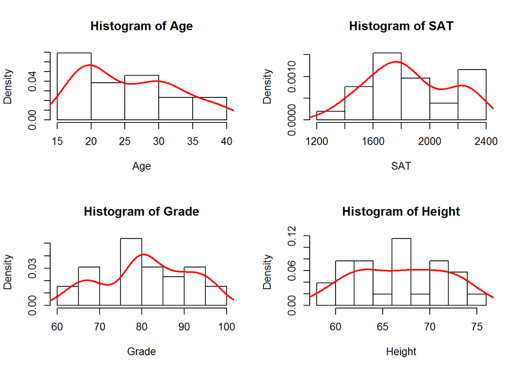

```r
attach(students_new);
par(mfrow=c(2,2));
hist(Age, freq=F, main='Histogram of Age');
lines(density(Age), col=2, lty=1, lwd=2);
hist(SAT,freq=F, main='Histogram of SAT');
lines(density(SAT), col=2, lty=1, lwd=2);
hist(Grade,freq=F, main='Histogram of Grade');
lines(density(Grade), col=2, lty=1, lwd=2);
hist(Height,freq=F, main='Histogram of Height');
lines(density(Height), col=2, lty=1, lwd=2);
```

### Box plots

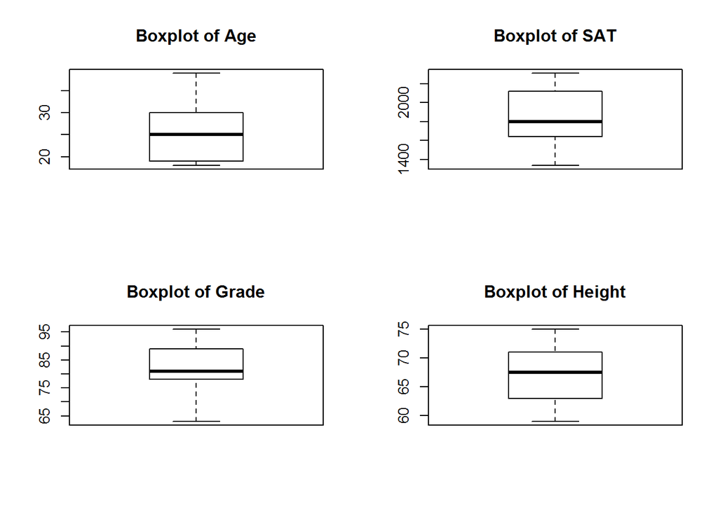

```r
par(mfrow=c(2,2));
boxplot(Age, main='Boxplot of Age');
boxplot(SAT, main='Boxplot of SAT');
boxplot(Grade, main='Boxplot of Grade');
boxplot(Height, main='Boxplot of Height');
```

```r
#There are no outliers
```

###Box plots by Gender

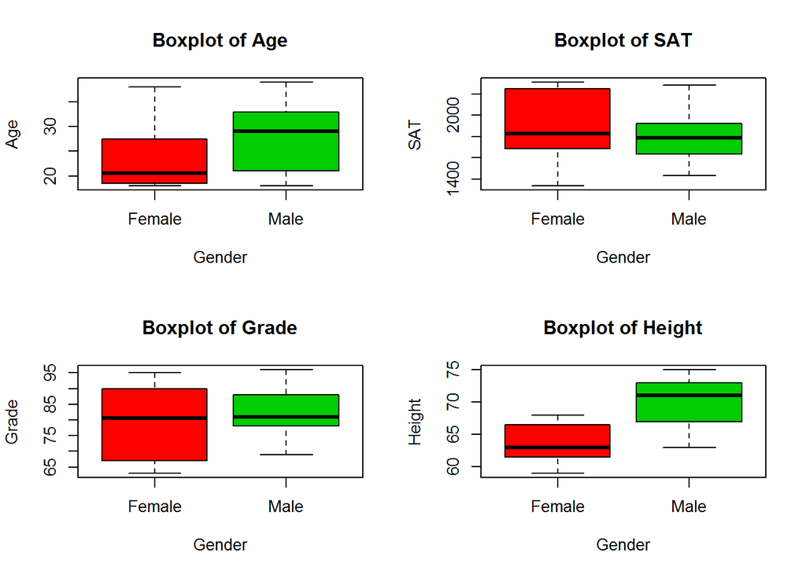

```r
par(mfrow=c(2,2));
boxplot(Age~Gender, main='Boxplot of Age',col=c(2,3));
boxplot(SAT~Gender, main='Boxplot of SAT',col=c(2,3));
boxplot(Grade~Gender, main='Boxplot of Grade',col=c(2,3));
boxplot(Height~Gender, main='Boxplot of Height',col=c(2,3));
```

```r
#There are no outliers
```

### Scatter plot matrix

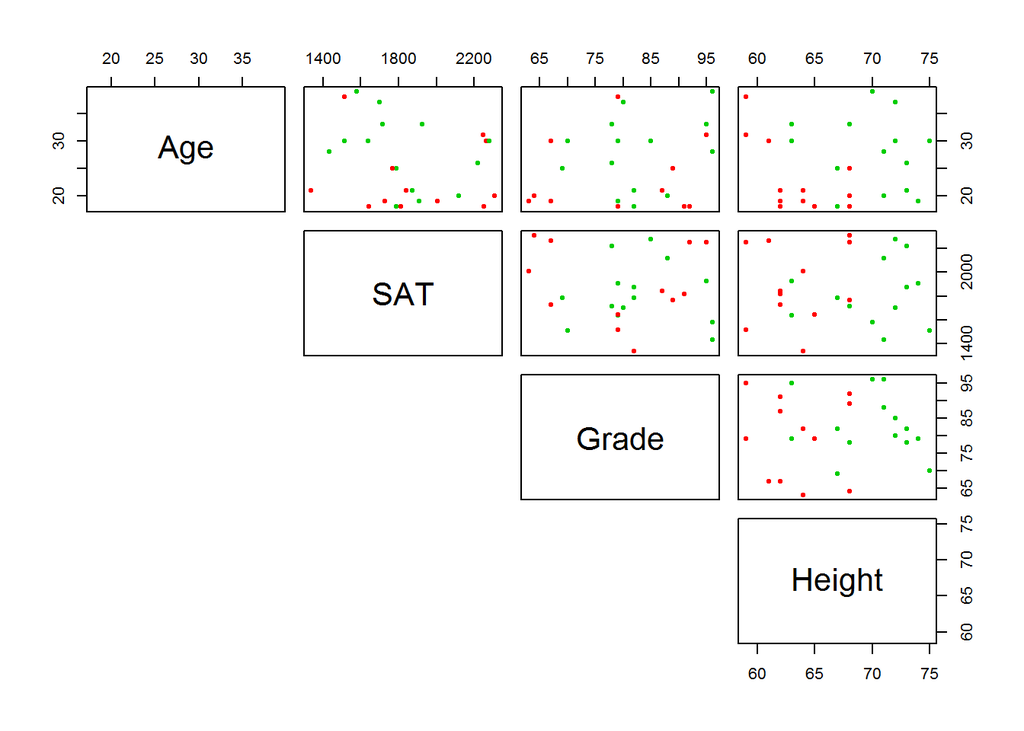

```r
pairs(~Age+SAT+Grade+Height,col = c(2,3)[Gender],pch=20, data=students_new,lower.panel = NULL);
```

### Categorical data visualizations

```r
counts= table(Gender);
counts;
```

```
## Gender
## Female   Male
##     12     14
```

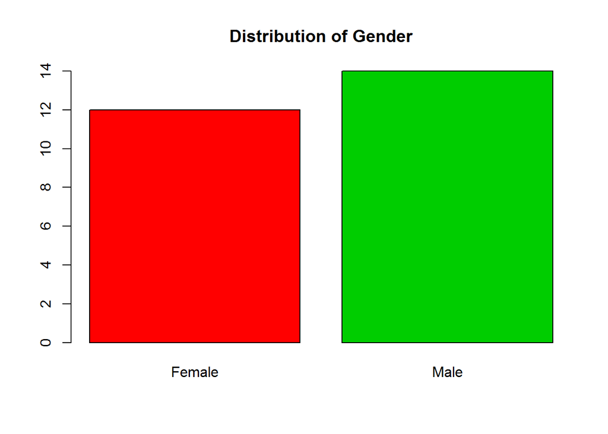

```r
barplot(counts,main="Distribution of Gender",
col=c(2,3),names.arg=c("Female", "Male"));
```

- Add another binary varialbe `SAT1800`: 1 if SAT >= 1800; 0 otherwise

```r
students_new$SAT1800=ifelse(SAT >= 1800, 1,0);
table=table(students_new$Gender, students_new$SAT1800);  #Construct a Crosstable
table;
```

```
##
##          0 1
##   Female 5 7
##   Male   8 6
```

```r
detach(students_new);
```